# Chapter 4

## Exercise 13

```python
import numpy as np
import pandas as pd
import matplotlib.pyplot as plt
import statsmodels.api as sm
import ISLP
from ISLP import load_data
from ISLP.models import (ModelSpec as MS,summarize)
import seaborn as sns
from sklearn.discriminant_analysis import \
     (LinearDiscriminantAnalysis as LDA,
      QuadraticDiscriminantAnalysis as QDA)
from sklearn.naive_bayes import GaussianNB
from sklearn.neighbors import KNeighborsClassifier
```

```python
Weekly=load_data("Weekly")
```

```python
Weekly.head()
```

|  | Year | Lag1 | Lag2 | Lag3 | Lag4 | Lag5 | Volume | Today | Direction |
| --- | --- | --- | --- | --- | --- | --- | --- | --- | --- |
| 0 | 1990 | 0.816 | 1.572 | -3.936 | -0.229 | -3.484 | 0.154976 | -0.270 | Down |
| 1 | 1990 | -0.270 | 0.816 | 1.572 | -3.936 | -0.229 | 0.148574 | -2.576 | Down |
| 2 | 1990 | -2.576 | -0.270 | 0.816 | 1.572 | -3.936 | 0.159837 | 3.514 | Up |
| 3 | 1990 | 3.514 | -2.576 | -0.270 | 0.816 | 1.572 | 0.161630 | 0.712 | Up |
| 4 | 1990 | 0.712 | 3.514 | -2.576 | -0.270 | 0.816 | 0.153728 | 1.178 | Up |

### (a)

First step to look for patterns is to draw statistical description of data. For this we can use the method describe() as follows:

```python
Weekly.describe?
```

[output not shown]

[output cut: 186 more lines]

[output not shown]

```python
Weekly.describe()
```

|  | Year | Lag1 | Lag2 | Lag3 | Lag4 | Lag5 | Volume | Today |
| --- | --- | --- | --- | --- | --- | --- | --- | --- |
| count | 1089.000000 | 1089.000000 | 1089.000000 | 1089.000000 | 1089.000000 | 1089.000000 | 1089.000000 | 1089.000000 |
| mean | 2000.048669 | 0.150585 | 0.151079 | 0.147205 | 0.145818 | 0.139893 | 1.574618 | 0.149899 |
| std | 6.033182 | 2.357013 | 2.357254 | 2.360502 | 2.360279 | 2.361285 | 1.686636 | 2.356927 |
| min | 1990.000000 | -18.195000 | -18.195000 | -18.195000 | -18.195000 | -18.195000 | 0.087465 | -18.195000 |
| 25% | 1995.000000 | -1.154000 | -1.154000 | -1.158000 | -1.158000 | -1.166000 | 0.332022 | -1.154000 |
| 50% | 2000.000000 | 0.241000 | 0.241000 | 0.241000 | 0.238000 | 0.234000 | 1.002680 | 0.241000 |
| 75% | 2005.000000 | 1.405000 | 1.409000 | 1.409000 | 1.409000 | 1.405000 | 2.053727 | 1.405000 |
| max | 2010.000000 | 12.026000 | 12.026000 | 12.026000 | 12.026000 | 12.026000 | 9.328214 | 12.026000 |

```python
Weekly.corr?
```

[output not shown]

[output cut: 18 more lines]

[output not shown]

```python
Weekly.corr(numeric_only=True)
```

|  | Year | Lag1 | Lag2 | Lag3 | Lag4 | Lag5 | Volume | Today |
| --- | --- | --- | --- | --- | --- | --- | --- | --- |
| Year | 1.000000 | -0.032289 | -0.033390 | -0.030006 | -0.031128 | -0.030519 | 0.841942 | -0.032460 |
| Lag1 | -0.032289 | 1.000000 | -0.074853 | 0.058636 | -0.071274 | -0.008183 | -0.064951 | -0.075032 |
| Lag2 | -0.033390 | -0.074853 | 1.000000 | -0.075721 | 0.058382 | -0.072499 | -0.085513 | 0.059167 |
| Lag3 | -0.030006 | 0.058636 | -0.075721 | 1.000000 | -0.075396 | 0.060657 | -0.069288 | -0.071244 |
| Lag4 | -0.031128 | -0.071274 | 0.058382 | -0.075396 | 1.000000 | -0.075675 | -0.061075 | -0.007826 |
| Lag5 | -0.030519 | -0.008183 | -0.072499 | 0.060657 | -0.075675 | 1.000000 | -0.058517 | 0.011013 |
| Volume | 0.841942 | -0.064951 | -0.085513 | -0.069288 | -0.061075 | -0.058517 | 1.000000 | -0.033078 |
| Today | -0.032460 | -0.075032 | 0.059167 | -0.071244 | -0.007826 | 0.011013 | -0.033078 | 1.000000 |

Thanks to the correlation matrix, the only predictible trend is between Volume and Year. But let's draw graphs as the question asks.

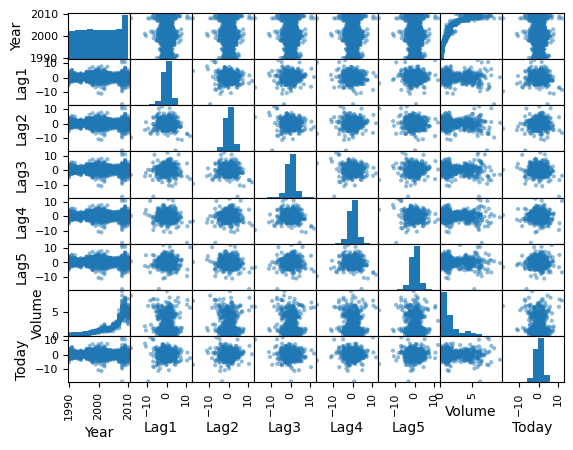

```python
pd.plotting.scatter_matrix(Weekly);
```

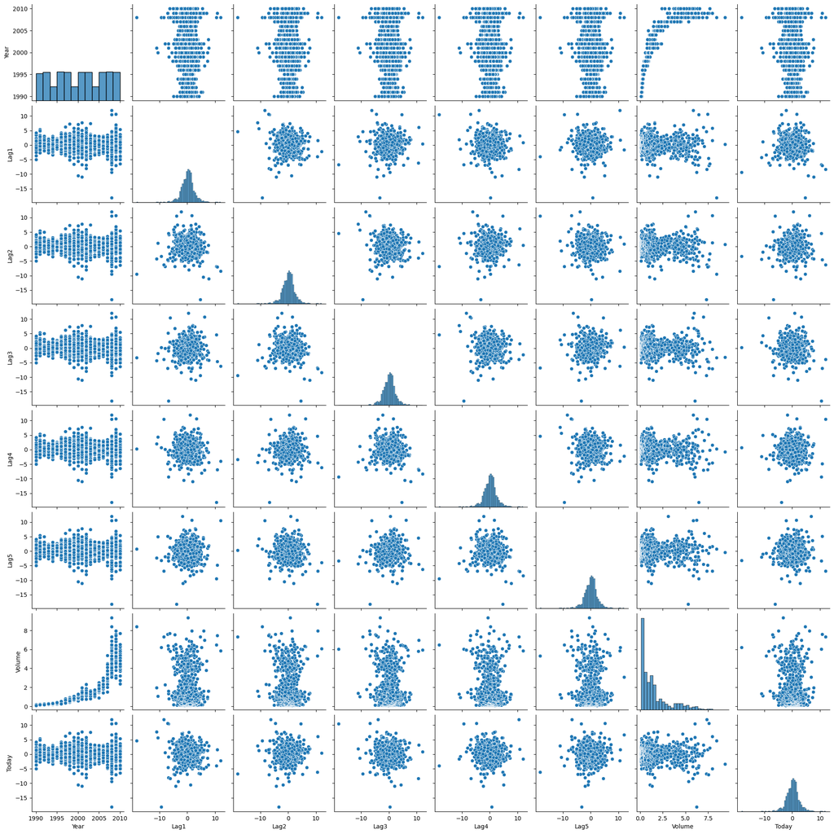

```python
sns.pairplot(Weekly);
```

As observed, seaborn provides us with a more readable scatter matrix.

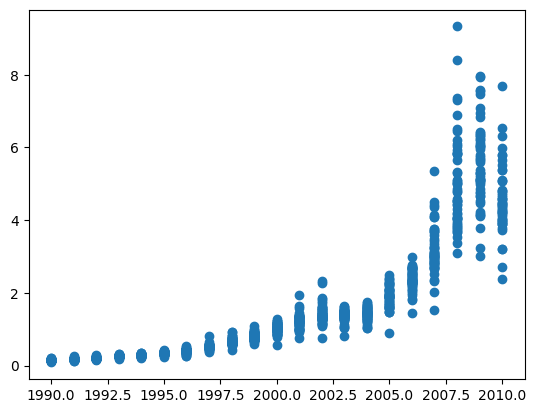

```python
plt.scatter(Weekly['Year'],Weekly['Volume']);
```

Given the plots shown above, the only visible pattern is the one which relates Year to Volume

### (b)

```python
allvars=Weekly.columns.drop(['Today','Direction','Year'])
design=MS(allvars)
X=design.fit_transform(Weekly)
y=Weekly.Direction=='Up'
glm=sm.GLM(y,X,family=sm.families.Binomial())
res=glm.fit()
res.summary()
```

Generalized Linear Model Regression Results

| Dep. Variable: | Direction | No. Observations: | 1089 |
| --- | --- | --- | --- |
| Model: | GLM | Df Residuals: | 1082 |
| Model Family: | Binomial | Df Model: | 6 |
| Link Function: | Logit | Scale: | 1.0000 |
| Method: | IRLS | Log-Likelihood: | -743.18 |
| Date: | Mon, 16 Mar 2026 | Deviance: | 1486.4 |
| Time: | 12:45:31 | Pearson chi2: | 1.09e+03 |
| No. Iterations: | 4 | Pseudo R-squ. (CS): | 0.009000 |
| Covariance Type: | nonrobust |  |  |

|  | coef | std err | z | P>\|z\| | [0.025 | 0.975] |
| --- | --- | --- | --- | --- | --- | --- |
| intercept | 0.2669 | 0.086 | 3.106 | 0.002 | 0.098 | 0.435 |
| Lag1 | -0.0413 | 0.026 | -1.563 | 0.118 | -0.093 | 0.010 |
| Lag2 | 0.0584 | 0.027 | 2.175 | 0.030 | 0.006 | 0.111 |
| Lag3 | -0.0161 | 0.027 | -0.602 | 0.547 | -0.068 | 0.036 |
| Lag4 | -0.0278 | 0.026 | -1.050 | 0.294 | -0.080 | 0.024 |
| Lag5 | -0.0145 | 0.026 | -0.549 | 0.583 | -0.066 | 0.037 |
| Volume | -0.0227 | 0.037 | -0.616 | 0.538 | -0.095 | 0.050 |

Only Lag2 seems to be statistically significant.

### (c)

```python
probs=res.predict()
labels=np.array(['Down']*1089)
labels[probs>0.5]="Up"
```

```python
ISLP.confusion_table(labels,Weekly.Direction)
```

| Truth Predicted | Down | Up |
| --- | --- | --- |
| Down | 54 | 48 |
| Up | 430 | 557 |

```python
(557+54)/(54+557+430+48)
```

```
0.5610651974288338
```

The accuracy rate is 56%, slightly better than random guessing. Given that we chose that 'up' is the positive direction, the error rate is mainly due to false positive classification. Which means that 430 stocks are predicted to go up by the model while they truly go down.

### (d)

```python
# Selecting the asked period and the corresponding training set with Lag2 as the only predictor
train=(Weekly.Year<2009)
W_train=Weekly.loc[train].Lag2
W_test=Weekly.loc[~train].Lag2
W_test.shape
```

```
(104,)
```

```python
#Refitting the new model
X_train, X_test = X.loc[train].Lag2, X.loc[~train].Lag2
y_train, y_test = y.loc[train], y.loc[~train]
glm_train = sm.GLM(y_train,
                   X_train,
                   family=sm.families.Binomial())
results = glm_train.fit()
#Designing the probabilities based on the training set
probs = results.predict(exog=X_test)

#For LDA, QDA, and KNN
X_t=np.array(X_train)
XX=X_t.reshape(np.shape(X_t)[0],1)
X_ts=np.array(X_test)
Xts=X_ts.reshape(np.shape(X_ts)[0],1)
```

```python
#Preparing the test set to compare with the corresponding training set in the confusion matrix
D=Weekly.Direction
Test_set=D.loc[~train]
Train_set=D.loc[train]
#Converting the probs matrix to a matrix filled with direction values
labels=np.array(['Down']*104)
labels[probs>0.5]='Up'
C=ISLP.confusion_table(labels,Test_set)

Test_s=np.array(Test_set)
TS=Test_s.reshape(np.shape(Test_s)[0],1)
TS.shape
```

```
(104, 1)
```

```python
C
```

| Truth Predicted | Down | Up |
| --- | --- | --- |
| Down | 20 | 24 |
| Up | 23 | 37 |

```python
(20+37)/104
```

```
0.5480769230769231
```

The rate of correct predictions on the held out data is around 55%.

### (e)

```python
lda=LDA(store_covariance=True)
lda.fit(XX, Train_set)
```

```
LinearDiscriminantAnalysis(store_covariance=True)
```

```python
lda_pred=lda.predict(Xts)
lda_predm=np.array(lda_pred)
lda_predm1=lda_predm.reshape(np.shape(lda_predm)[0],1)
ISLP.confusion_table(lda_predm1,TS)
```

| Truth Predicted | Down | Up |
| --- | --- | --- |
| Down | 9 | 5 |
| Up | 34 | 56 |

```python
(9+56)/104
```

```
0.625
```

LDA performs better than logistic regression since Lag2 seems to follow a normal distribution from the previous correlation plot.

### (f)

```python
qda=QDA(store_covariance=True)
qda.fit(XX, Train_set)
```

```
QuadraticDiscriminantAnalysis(store_covariance=True)
```

```python
qda_pred=qda.predict(Xts)
qda_predm=np.array(qda_pred)
qda_predm1=qda_predm.reshape(np.shape(lda_predm)[0],1)
ISLP.confusion_table(qda_predm1,TS)
```

| Truth Predicted | Down | Up |
| --- | --- | --- |
| Down | 0 | 0 |
| Up | 43 | 61 |

```python
61/(61+43)
```

```
0.5865384615384616
```

Fraction of correct answers for QDA is around 59%, which means that it is lower than LDA but better than logistic regression. The QDA is better here than logistic regression for the same reason as for the LDA. However, LDA gives a better prediction than QDA since there are no signs of interactions among predictors.

### (g)

```python
knn1 = KNeighborsClassifier(n_neighbors=1)
knn1.fit(XX, Train_set)
```

```
KNeighborsClassifier(n_neighbors=1)
```

```python
knn1_pred=knn1.predict(Xts)
knn1_predm=np.array(knn1_pred)
knn1_predm1=knn1_predm.reshape(np.shape(knn1_predm)[0],1)
ISLP.confusion_table(knn1_predm1,TS)
```

| Truth Predicted | Down | Up |
| --- | --- | --- |
| Down | 22 | 31 |
| Up | 21 | 30 |

```python
(22+30)/104
```

```
0.5
```

### (h)

```python
NB = GaussianNB()
NB.fit(XX, Train_set)
```

```
GaussianNB()
```

```python
NB_pred=NB.predict(Xts)
NB_predm=np.array(NB_pred)
NB_predm1=NB_predm.reshape(np.shape(NB_predm)[0],1)
ISLP.confusion_table(NB_predm1,TS)
```

| Truth Predicted | Down | Up |
| --- | --- | --- |
| Down | 0 | 0 |
| Up | 43 | 61 |

```python
61/104
```

```
0.5865384615384616
```

### (i)

LDA appears to give the best results on the data set.